# Prediction Assignment Writeup

Ignas

19/04/2020

## Background

Using devices such as Jawbone Up, Nike FuelBand, and Fitbit it is now possible to collect a large amount of data about personal activity relatively inexpensively.The goal is to use data from accelerometers on the belt, forearm, arm, and dumbell of 6 participants who were asked to perform barbell lifts correctly and incorrectly in 5 different ways.

## Task

The goal of this project is to predict the manner in which they did the exercise and build prediction model to predict 20 different test cases.

# Data preparation

Let’s load necessary libraries and import the data.

```r
library(rpart)
library(rattle)
library(caret)
library(randomForest)
set.seed(12345)

# Training and Testing data
TrainURL <- "https://d396qusza40orc.cloudfront.net/predmachlearn/pml-training.csv"
TestURL <- "https://d396qusza40orc.cloudfront.net/predmachlearn/pml-testing.csv"

# Download and clean the datasets
trainingdata <- read.csv(url(TrainURL), na.strings=c("NA","#DIV/0!",""))
testingdata <- read.csv(url(TestURL), na.strings=c("NA","#DIV/0!",""))
```

Dimensions of downloaded data

```r
dim(trainingdata); dim(testingdata)
```

```
[1] 19622   160
```

```
[1]  20 160
```

Summary of the data (as the data is quite large, summary results are not provided).

```r
str(trainingdata); str(testingdata)
```

Let’s delete columns with NA values and delete unnecessary columns:

```r
trainingdata <-trainingdata[,colSums(is.na(trainingdata)) == 0]
testingdata <-testingdata[,colSums(is.na(testingdata)) == 0]

trainingdata <-trainingdata[,-c(1:7)]
testingdata <-testingdata[,-c(1:7)]

dim(trainingdata); dim(testingdata)
```

```
[1] 19622    53
```

```
[1] 20 53
```

## Data partition

In order to be able to apply cross-validation, data will be splitted into 70% of Training data and 30 percent of Testing data.

```r
datapart <- createDataPartition(trainingdata$classe, p=0.7, list=FALSE)
trainingset <- trainingdata[datapart, ]
testingset <- trainingdata[-datapart, ]
dim(trainingset);dim(testingset)
```

```
## [1] 13737    53
```

```
## [1] 5885   53
```

```r
summary(testingset$classe)
```

```
##    A    B    C    D    E
## 1674 1139 1026  964 1082
```

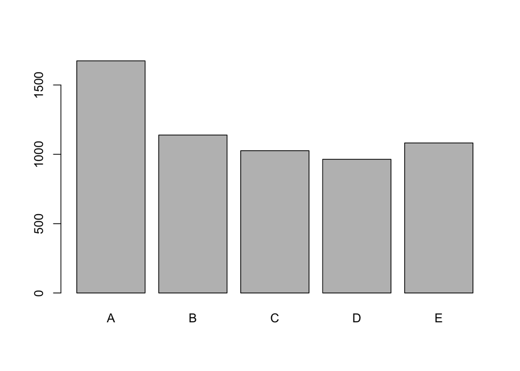

```r
plot(testingset$classe)
```

We see that there are 5 classes where A is the most frequent and D is at least frequent. However, all of the 5 classes are distributed more or less the same.

## Prediction

In order to generate predictions, we will use decision tree and random forest models.

### 1. Decision tree model

```r
dtmod <- rpart(classe ~ ., data = trainingset, method = "class")
dtpred <- predict(dtmod, testingset, type = "class")
confusionMatrix(dtpred, testingset$classe)
```

```
## Confusion Matrix and Statistics
##
##           Reference
## Prediction    A    B    C    D    E
##          A 1498  196   69  106   25
##          B   42  669   85   86   92
##          C   43  136  739  129  131
##          D   33   85   98  553   44
##          E   58   53   35   90  790
##
## Overall Statistics
##
##                Accuracy : 0.722
##                  95% CI : (0.7104, 0.7334)
##     No Information Rate : 0.2845
##     P-Value [Acc > NIR] : < 2.2e-16
##
##                   Kappa : 0.6467
##
##  Mcnemar's Test P-Value : < 2.2e-16
##
## Statistics by Class:
##
##                      Class: A Class: B Class: C Class: D Class: E
## Sensitivity            0.8949   0.5874   0.7203  0.57365   0.7301
## Specificity            0.9060   0.9357   0.9097  0.94717   0.9509
## Pos Pred Value         0.7909   0.6869   0.6273  0.68020   0.7700
## Neg Pred Value         0.9559   0.9043   0.9390  0.91897   0.9399
## Prevalence             0.2845   0.1935   0.1743  0.16381   0.1839
## Detection Rate         0.2545   0.1137   0.1256  0.09397   0.1342
## Detection Prevalence   0.3218   0.1655   0.2002  0.13815   0.1743
## Balanced Accuracy      0.9004   0.7615   0.8150  0.76041   0.8405
```

Decision tree:

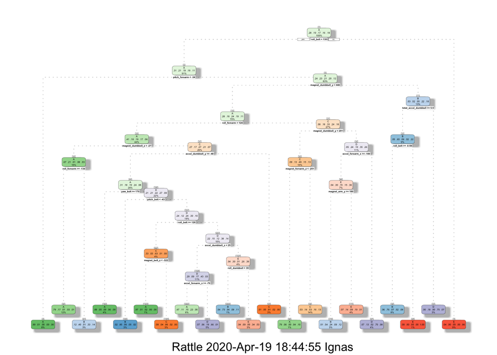

```r
fancyRpartPlot(dtmod)
```

### 2. Random forest model

```r
rfmod <- randomForest(classe ~., data=trainingset, method="class")
rfpred <- predict(rfmod, testingset, Type="class")
confusionMatrix(rfpred, testingset$classe)
```

```
## Confusion Matrix and Statistics
##
##           Reference
## Prediction    A    B    C    D    E
##          A 1673   10    0    0    0
##          B    1 1127   11    0    0
##          C    0    2 1015   13    0
##          D    0    0    0  951    4
##          E    0    0    0    0 1078
##
## Overall Statistics
##
##                Accuracy : 0.993
##                  95% CI : (0.9906, 0.995)
##     No Information Rate : 0.2845
##     P-Value [Acc > NIR] : < 2.2e-16
##
##                   Kappa : 0.9912
##
##  Mcnemar's Test P-Value : NA
##
## Statistics by Class:
##
##                      Class: A Class: B Class: C Class: D Class: E
## Sensitivity            0.9994   0.9895   0.9893   0.9865   0.9963
## Specificity            0.9976   0.9975   0.9969   0.9992   1.0000
## Pos Pred Value         0.9941   0.9895   0.9854   0.9958   1.0000
## Neg Pred Value         0.9998   0.9975   0.9977   0.9974   0.9992
## Prevalence             0.2845   0.1935   0.1743   0.1638   0.1839
## Detection Rate         0.2843   0.1915   0.1725   0.1616   0.1832
## Detection Prevalence   0.2860   0.1935   0.1750   0.1623   0.1832
## Balanced Accuracy      0.9985   0.9935   0.9931   0.9929   0.9982
```

## Conclusion

Accuracy of decision tree model is 72.2% while using random forest is 99.3%. Out-of-sample error is 0.7% (calculated as 1-ACCURACY).

The results are as we have expected, i.e. random forest model performs better than decision tree.

## Original test set prediction

Now the results will be applied on original test date (20 observations)

```r
ftest <- predict(rfmod, testingdata, type = "class")
ftest
```

```
##  1  2  3  4  5  6  7  8  9 10 11 12 13 14 15 16 17 18 19 20
##  B  A  B  A  A  E  D  B  A  A  B  C  B  A  E  E  A  B  B  B
## Levels: A B C D E
```

```r
write.csv(ftest, "final_prediction.csv")
```